# Distribuciones de Probabilidad Discretas con R

Eduardo Marín Nicolalde

_eemarin@espe.edu.ec_

# Lanzamiento de monedas

Lanzar monedas podría no parecer dificil en prinicipio sin embargo, R nos propone algunas funciones para hacer simulaciones de este experimento. Crearemos un vector con los dos posibles resultados del lanzamiento de una moneda y con ayuda de la función `sample()` simularemos los lanzamientos.

La función `sample(x, size, replace = FALSE)` tiene los siguientes argumentos:

- x : un vector de donde escoger los resultados
- size: el número de resultados (muestras) deseados.
- replace: verdadero (TRUE) o falso (FALSE) indicando si la muestra se realiza con reemplazo.

Para nuestros fines, utilizaremos reemplazo de manera que si las opciones "Cara" o "Sello" han salido en un lanzamiento, puedan aparecer en los lanzamientos subsecuentes.

Para simular 10 lanzamientos de una moneda, tenemos:

```r
moneda = c("Cara","Sello")
exp1   = sample(moneda, 10, replace = T)
exp1
```

1. 'Cara'

2. 'Sello'

3. 'Cara'

4. 'Sello'

5. 'Sello'

6. 'Cara'

7. 'Cara'

8. 'Cara'

9. 'Cara'

10. 'Cara'

Para contar el número de caras y monedas, utilizamos la función `table()`

```r
table(exp1)
```

```
exp1
 Cara Sello
    7     3
```

Si queremos obtener los resultados en términos relativos (proporciones), utilizamos la función `prop.table()` sobre el resultado de `table()`.

```r
prop.table(table(exp1))
```

```
exp1
 Cara Sello
  0.7   0.3
```

Recordemos que las proporciones pueden interpretarse como probabilidades. Ya que el experimento contiene solo diez lanzamientos, la probabilidad de cada una de las posibilidades no está acorde a lo que esperaríamos.

Simulemos el lanzamiento de 1'000.000 de monedas y observemos si las probabilides teóricas se cumplen.

```r
exp2   = sample(moneda, 1000000, replace = T)
prop.table(table(exp2))
```

```
exp2
    Cara    Sello
0.499547 0.500453
```

# Distribuciónes discretas

A continuación se enlistan las distribuciones discretas que analizaremos en el taller, acompañadas de su nombre en el ambiente de R:

1. Distribución binomial (`binom`)
2. Distribución de Poisson (`pois`)
3. Distribución binomial negativa (`nbinom`)
4. Distribución hipergeométrica (`hyper`)
5. Distribución multinomial (`multinom`)

Para las 4 primeras distribuciones, R permite permite utilizar las siguientes funciones:

- **Densidad:** Obtener la probabilidad $P(Y=y)$, es decir la probabilidad de que la variable aleatoria $Y$ tome un valor particular $y$. En R, antecedemos al nombre de la distribución de probabilidad con la letra "d".

  Así, si queremos obtener un valor $P(Y=y)$ para la distribución binomial, la función a utilizar es `dbinom`
- **Distribución:** También conocida como función de distribución acumulada, devuelve probabilidades acumuladas del tipo $P(Y \le y)$. En R, antecedemos al nombre de la distribución de probabilidad con la letra "p".

  Así, si queremos obtener $P(Y \le y)$ para la distribución hypergeométrica, la función a utilizar es `phyper`
- **Cuantiles:** Devuelve el valor $y_o$ que se ubica en un cuantil $p$ determinado. En otras palabras, obtenemos el valor $y_o$ que cumple $P(Y \le y_o)= p$. En R, antecedemos al nombre de la distribución de probabilidad con la letra "q".

  Así, si queremos obtener el valor $y_o$ tal que $P(Y \le y_o)= p$, para la distribución binomial negativa, la función a utilizar es `qnbinom`
- **Números aleatorios:** Permite simular valores aleatorios de $Y$ para una distribución seleccionada, conociendo los parámetros de la distribución. En R, antecedemos al nombre de la distribución de probabilidad con la letra "r".

  Así, si queremos obtener valores aleatorios de $Y$, para la distribución binomial, la función a utilizar es `rbinom`

Para la **distribución multinomial**, solamente están disponibles las opciones de densidad y *números aleatorios*.

# 1. Distribución Binomial

Sabemos que la variable aleatoria $Y \tilde{} Bin(n,p)$ se define como *el número de éxitos en n pruebas*.

Si deseamos conocer el valor de $P(Y=3)$: obtener 3 éxitos en, digamos, $n=15$ pruebas con probabilidad de éxito $p=0.6$; utilizamos la función de **densidad** binomial:

```dbinom(x, size, prob)```

Donde:

- **`x`** es el valor particular $y$
- **`size`** es el número de pruebas $n$
- **`prob`** es la probabilidad de éxito constante entre las pruebas

Para $P(Y=3)$ escribimos:

```r
dbinom(x=3, size=15, prob=0.6)
```

0.00164886478848

Supongamos que, para los mismos datos, deseamos obtener

$P(Y \le 3)=p(0)+p(1)+p(2)+p(3)$

Podríamos sumar los valores individuales de cada probabilidad obtenida con la función de **densidad** binomial:

```r
dbinom(0,15,0.6) + dbinom(1,15,0.6) + dbinom(2,15,0.6) +
dbinom(3,15,0.6)
```

0.001927769227264

O simplemente utilizar la función de **distribución** binomial:

```pbinom(q, size, prob, lower.tail = TRUE)```

Donde:

- **`q`** es el valor particular $y$
- **`size`** es el número de pruebas $n$
- **`prob`** es la probabilidad de éxito constante entre las pruebas
- **`lower.tail`** determina si la probabilidad devuelta es $P(Y \le y)$ (si `TRUE`) o $P(Y > y)$ (si `FALSE` )

Para $P(Y\le3)$ escribimos:

```r
pbinom(q=3, size=15, prob=0.6, lower.tail = TRUE)
```

0.001927769227264

Si deseamos conocer $P(Y > 3)$ escribimos:

```r
pbinom(3,15,0.6,FALSE)
```

0.998072230772736

Podemos confirmar que la suma de todas las probabilidades $P(Y \le 3)+P(Y > 3)=1$ :

```r
pbinom(3,15,0.6,T) + pbinom(3,15,0.6,F)
```

1

Para obtener la **distribución de probabilidad** de la variable aleatoria $Y$ podemos utilizar la función de **densidad** nuevamente, especificando todos los valores particulares como un vector en el argumento `x`.

```r
y    = 0:15
prob = dbinom(y,size=15,prob=0.6)
cbind(y, prob = round(prob,6))
```

| y | prob |
| --- | --- |
| 0 | 0.000001 |
| 1 | 0.000024 |
| 2 | 0.000254 |
| 3 | 0.001649 |
| 4 | 0.007420 |
| 5 | 0.024486 |
| 6 | 0.061214 |
| 7 | 0.118056 |
| 8 | 0.177084 |
| 9 | 0.206598 |
| 10 | 0.185938 |
| 11 | 0.126776 |
| 12 | 0.063388 |
| 13 | 0.021942 |
| 14 | 0.004702 |
| 15 | 0.000470 |

Se puede graficar la distribución de probabilidad utilizando la función `barplot()`. Utilizamos el argumento `space=0` para evitar el espacio entre las barras, simulando a un histograma.

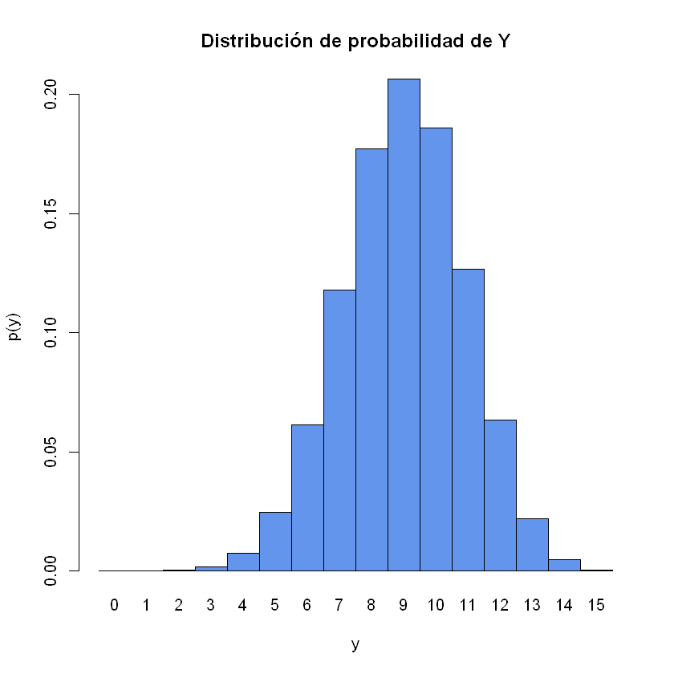

```r
barplot(prob, names.arg= 0:15,space=0,
        xlab = "y", ylab = "p(y)",
        main = "Distribución de probabilidad de Y",
        col  = "cornflowerblue")
```

Supongamos que estamos intersados en conocer el valor $y_o$ que tiene 0.2131 de probilidad a su izquierda. En otras palabras, deseamos conocer el valor $y_o$ que cumple con $P(Y \le y_0)= 0.2131$.

Para encontrar dicho valor utilizamos la función

```qbinom(p, size, prob, lower.tail = TRUE)```

Donde:

- **`p`** es la probabilidad a la izquierda/derecha de $y_0$. Ver `lower.tail`.
- **`size`** es el número de pruebas $n$
- **`prob`** es la probabilidad de éxito constante entre las pruebas
- **`lower.tail`** determina si el valor $y_0$ a devolver, cumple con $P(Y \le y_0)= p$ (si `TRUE`) o $P(Y > y_0)= p$ (si `FALSE` )

Para encontrar el $y_0$ que cumple con $P(Y \le y_0)= 0.2131$, escribimos:

```r
qbinom(p=0.2131, size=15, prob=0.6, lower.tail = TRUE)
```

7

Comprobamos la respuesta $y_o=7$ con la función de **distribución** `pbinom()`, buscando la probabilidad $P(Y \le 7)$

```r
pbinom(7,size=15,prob=0.6,lower.tail = TRUE)
```

0.213103182610432

Finalmente, podemos generar valores aleatorios de $Y$ con la función

```rbinom(n, size, prob)```

Donde:

- **`n`** es el número de datos aleatorios a generar.
- **`size`** es el número de pruebas $n$
- **`prob`** es la probabilidad de éxito constante entre las pruebas

Para generar 20 valores aleatorios de $Y$:el número de éxitos es $n$ pruebas, escribimos:

```r
set.seed(3)
sim = rbinom(n=20, size=15, prob=0.6)
sim
```

1. 11

2. 7

3. 10

4. 10

5. 9

6. 9

7. 11

8. 10

9. 9

10. 8

11. 9

12. 9

13. 9

14. 9

15. 7

16. 7

17. 11

18. 8

19. 7

20. 10

Cada valor representa una simulación del número de éxitos para $Y \tilde{} Bin(n=15,p=0.6)$. Recordemos que la **esperanza** de una variable aleatoria binomial está dada por $E[Y]=np$, tenemos:

```r
15*0.6
```

9

Recordando que la **esperanza matemática** es un promedio, podemos aproximar la esperanza de una distribución con la **media aritmética** de los datos simulados.

```r
mean(sim)
```

9

# 2. Distribución Poisson

Sabemos que la variable aleatoria $Y \tilde{} Pois(\lambda)$ se define como *el número de veces en que ocurre un evento en un intervalo fijo de tiempo o espacio*. Donde $\lambda$ es el promedio de eventos por intervalo e $y=0,1,2,...$

Supongamos que deseamos modelar el número de goles en un partido de fútbol. La información recabada nos indica que el promedio de goles en un partido de la Copa Mundial es $\lambda=2.5$. Para conocer la probabilidad de que se marquen 3 goles en un partido $P(Y=3)$; utilizamos la función de **densidad** Poisson:

```dpois(x, lambda)```

Donde:

- **`x`** es el valor particular $y$
- **`lambda`** es el promedio de sucesos del evento a estudiar $\lambda$

Para $P(Y=3)$ escribimos:

```r
dpois(x=3, lambda=2.5)
```

0.213763017249736

Supongamos que deseamos obtener la probabilidad de obtener no más de 4 goles en un partido

$P(Y \le 4)=p(0)+p(1)+p(2)+p(3)+p(4)$

Utilizamos la función de **distribución** Poisson:

```ppois(q, lambda, lower.tail = TRUE)```

Donde:

- **`q`** es el valor particular $y$
- **`lambda`** es el promedio de sucesos del evento a estudiar $\lambda$
- **`lower.tail`** determina si la probabilidad devuelta es $P(Y \le y)$ (si `TRUE`) o $P(Y > y)$ (si `FALSE` )

Para $P(Y\le 4)$ escribimos:

```r
ppois(q=4, lambda=2.5, lower.tail = TRUE)
```

0.891178018914151

Supongamos que estamos intersados en conocer el valor $y_o$ que tiene 0.5438 de probilidad a su izquierda. En otras palabras, deseamos conocer el valor $y_o$ que cumple con $P(Y \le y_0)= 0.5438$.

Para encontrar dicho valor utilizamos la función

```qpois(p, lambda, lower.tail = TRUE)```

Donde:

- **`p`** es la probabilidad a la izquierda/derecha de $y_0$. Ver `lower.tail`.
- **`lambda`** es el promedio de sucesos del evento a estudiar $\lambda$
- **`lower.tail`** determina si el valor $y_0$ a devolver, cumple con $P(Y \le y_0)= p$ (si `TRUE`) o $P(Y > y_0)= p$ (si `FALSE` )

Para encontrar el $y_0$ que cumple con $P(Y \le y_0)= 0.5438$, escribimos:

```r
qpois(p=0.5438, lambda=2.5, lower.tail = TRUE)
```

2

Finalmente, podemos generar valores aleatorios de $Y:$ el número de goles en un partido, con la función

```rpois(n, lambda)```

Donde:

- **`n`** es el número de datos aleatorios a generar.
- **`lambda`** es el promedio de sucesos del evento a estudiar $\lambda$

Para simular el número de goles en 30 partidos escribimos:

```r
sim2 = rpois(n=30, lambda=2.5)
sim2
```

1. 1

2. 0

3. 1

4. 1

5. 1

6. 4

7. 3

8. 5

9. 3

10. 3

11. 2

12. 2

13. 1

14. 2

15. 1

16. 2

17. 4

18. 1

19. 3

20. 1

21. 1

22. 4

23. 1

24. 3

25. 2

26. 1

27. 0

28. 1

29. 2

30. 4

# 3. Distribución Binomial Negativa

Sabemos que la variable aleatoria $Y \tilde{} BinNeg(r,p)$ se define como *el número de pruebas para obtener el r-ésimo éxito*. Donde $y=r,(r+1)(r+2),...$

Supongamos que deseamos hacer un modelo del número casas a visitar para vender 6 empaques de galletas en un barrio y que solo se puede vender un paquete por casa. La probabilidad de vender un paquete en cada casa es 0.6. Si deseamos conocer la probabilidad de vender el 6to paquete de galletas en la décima casa; utilizamos la función de **densidad** Binomial Negativa:

```dnbinom(x, size, prob)```

Donde:

- **`x`** es el número de fracasos esperado $y-r$
- **`size`** es el número de éxitos deseado $r$
- **`prob`** es la probabilidad de éxito constante entre las pruebas.

**Adevertencia:** A pesar de que el argumento `x` se ingresa como el número de fracasos, la probabilidad que devuelve la función `dnbinom` es la **probabilidad de obtener $r$ éxitos haciendo $y$ pruebas** .

Para obtener $P(Y=10)$, con $r=6$ y $p=0.6$ escribimos:

```r
dnbinom(x=10-6, size=6, prob=0.6)
```

0.1504935936

Supongamos que deseamos obtener la probabilidad de que se necesite visitar menos de 15 casas para vender los 6 paquetes de galletas

$P(Y < 15)=P(Y \le 14)=p(6)+p(7)+...+p(14)$

Utilizamos la función de **distribución** Binomial Negativa:

```pnbinom(q, size, prob, lower.tail = TRUE)```

Donde:

- **`q`** es $(y-r)$ : la diferencia entre el valor particular y el número de éxitos deseados.
- **`size`** es el número de éxitos deseado $r$
- **`prob`** es la probabilidad de éxito constante entre las pruebas.
- **`lower.tail`** determina si la probabilidad devuelta es $P(Y \le y)$ (si `TRUE`) o $P(Y > y)$ (si `FALSE` )

Para $P(Y\le 14)$ escribimos:

```r
pnbinom(q=14-6, size=6, prob=0.6, lower.tail = TRUE)
```

0.94168105500672

Supongamos que estamos intersados en conocer el número de pruebas $y_o$ necesarias para asegurar la venta del 75,3% de paquetes a vender (queremos vender 6 paquetes). En otras palabras, deseamos conocer el valor $y_o$ que cumple con $P(Y \le y_0)= 0.753$.

Para encontrar dicho valor utilizamos la función

```qnbinom(p, size, prob,lower.tail = TRUE)```

Donde:

- **`p`** es la probabilidad a la izquierda/derecha de $y_0$. Ver `lower.tail`.
- **`size`** es el número de éxitos deseado $r$
- **`prob`** es la probabilidad de éxito constante entre las pruebas.
- **`lower.tail`** determina si la probabilidad devuelta es $P(Y \le y)$ (si `TRUE`) o $P(Y > y)$ (si `FALSE` )

**Advertencia:** El resultado devuelto por la función `qnbinom` corresponde a $(y_0 - r$): la diferencia del número de de pruebas necesarias para obtener la probabilidad deseada y el número de éxitos. Así, para obtener $y_0$ es necesario sumar el número de éxitos al resultado obtenido.

Para encontrar $y_0$ que cumple con $P(Y \le y_0)= 0.753$, escribimos:

```r
exitos = 6
y0_r   = qnbinom(p= 0.753, size= exitos, prob=0.6,
                 lower.tail = TRUE)
y0_r   + exitos
```

11

Finalmente, podemos generar valores aleatorios de $Y:$ el número de casas a visitar para vender 6 paquetes de galletas.

```rnbinom(n, size, prob)```

Donde:

- **`n`** es el número de datos aleatorios a generar.
- **`size`** es el número de éxitos deseado $r$
- **`prob`** es la probabilidad de éxito constante entre las pruebas.

**Advertencia:** El resultado devuelto por la función `rnbinom` corresponde a $(y - r$): la diferencia del número de de pruebas necesarias para obtener la probabilidad deseada y el número de éxitos. Así, para obtener $y$ es necesario sumar el número de éxitos al resultado obtenido.

Para simular 25 veces el número de casas a visitar para vender 6 paquetes de galletas, escribimos:

```r
exitos = 6
sim3 = rnbinom(n=25, size=6, prob=0.6)
sim3 + exitos
```

1. 13

2. 11

3. 10

4. 13

5. 7

6. 14

7. 13

8. 9

9. 10

10. 6

11. 6

12. 11

13. 7

14. 11

15. 8

16. 8

17. 9

18. 9

19. 11

20. 9

21. 8

22. 11

23. 8

24. 10

25. 11

# 4. Distribución Hipergeométrica

Modelamos la variable aleatoria $Y \tilde{} Hyper(N,n,r)$ el número de elementos de interés en la muestra.

Donde $N$ es el número total de elementos en la población, $r$ es el número de elementos de interés en la población, $n$ es el número de elementos en la muestra y $y=0,1,...,n$ bajo las restricciones $y \le r$ y $(n-y) \le (N-r)$.

Supongamos que tenemos una urna con 100 pelotas de las cuales 67 son doradas. Si deseamos conocer la probabilidad de obtener 15 pelotas doradas en una muestra de 20 pelotas obtenidas aleatoriamente y sin remplazo desde la urna; utilizamos la función de **densidad** Hipergeométrica:

```dhyper(x, m, n, k)```

Donde:

- **`x`** es el valor particular $y$
- **`m`** es el número de elementos de interés en la población $r$
- **`n`** es el número de elementos que no son de interés en la población $N-r$
- **`k`** es el número de elementos en la muestra $n$

Para obtener $P(Y=15)$ con $N=100$, $n=20$ y $r=67$, escribimos:

```r
dhyper(x=15, m= 67, n=100-67 , k=20)
```

0.153113432336166

Supongamos que deseamos conocer la probabilidad de obtener al menos 15 pelotas doradas en una muestra de 20 pelotas

$P(Y \ge 15)=P(Y > 14)=p(15)+p(16)+...+p(20)$

Utilizamos la función de **distribución** Hipergeométrica:

```phyper(q, m, n, k, lower.tail = TRUE)```

Donde:

- **`q`** es el valor particular $y$
- **`m`** es el número de elementos de interés en la población $r$
- **`n`** es el número de elementos que no son de interés en la población $N-r$
- **`k`** es el número de elementos en la muestra $n$
- **`lower.tail`** determina si la probabilidad devuelta es $P(Y \le y)$ (si `TRUE`) o $P(Y > y)$ (si `FALSE` )

Para $P(Y \ge 15)=P(Y > 14)$ escribimos:

```r
phyper(q=14, m=67, n=100-67 , k=20, lower.tail = FALSE)
```

0.284048826166228

Supongamos que estamos interesados en conocer $y_o$, el número de pelotas doradas en la muestra que tienen 0.1309 de probabilidad a su izquierda. En otras palabras, deseamos conocer el valor $y_o$ que cumple con $P(Y \le y_0)= 0.1309$.

Para encontrar dicho valor utilizamos la función

```qhyper(p, m, n, k, lower.tail = TRUE)```

Donde:

- **`p`** es la probabilidad a la izquierda/derecha de $y_0$. Ver `lower.tail`.
- **`m`** es el número de elementos de interés en la población $r$
- **`n`** es el número de elementos que no son de interés en la población $N-r$
- **`k`** es el número de elementos en la muestra $n$
- **`lower.tail`** determina si la probabilidad devuelta es $P(Y \le y)$ (si `TRUE`) o $P(Y > y)$ (si `FALSE` )

Para encontrar $y_0$ que cumple con $P(Y \le y_0)= 0.1309$, escribimos:

```r
qhyper(p=0.1309, m=67, n=100-67 , k=20, lower.tail = TRUE)
```

11

Finalmente, podemos generar valores aleatorios de $Y:$ el número elementos de interés en la muestra.

```rhyper(nn, m, n, k)```

Donde:

- **`nn`** es el número de datos aleatorios a generar.
- **`m`** es el número de elementos de interés en la población $r$
- **`n`** es el número de elementos que no son de interés en la población $N-r$
- **`k`** es el número de elementos en la muestra $n$

Para simular 14 veces el número pelotas doradas en la muestra, escribimos:

```r
rhyper(nn=14, m=67, n=100-67, k=20)
```

1. 15

2. 13

3. 12

4. 13

5. 15

6. 12

7. 16

8. 11

9. 14

10. 13

11. 15

12. 15

13. 16

14. 14

# 5. Distribución Multinomial

Sabemos que la variable aleatoria $Y \tilde{} Multinom(n,p_1,...,p_k)$ se define como *el número de éxitos en cada una de las $k$ categorías disponibles*.

Si para tres categorías tenemos $p_1=0.35$, $p_2=0.55$ y $p_3=0.1$ y deseamos conocer el valor de $P(Y_1=3,Y_2=5,Y_3=1)$: obtener 3,5 o 1 éxitos en las categorías 1, 2 y 3, respectivamente; utilizamos la función de **densidad** Multinomial:

```dmultinom(x, prob)```

Donde:

- **`x`** es el vector de valores particulares $y_i$
- **`prob`** es el vector de probabilidades de éxito $p_i$

Para $P(Y_1=3,Y_2=5,Y_3=1)$ escribimos:

```r
y_i = c(3,5,1)
p_i = c(0.35,0.55,0.1)
dmultinom(x=y_i, prob=p_i)
```

0.10875472059375

Finalmente, podemos generar valores aleatorios de $Y$ con la función

```rmultinom(n, size, prob)```

Donde:

- **`n`** es el número de datos aleatorios a generar.
- **`size`** es el número total de elementos a repartir en las $k$ categorías
- **`prob`** es el vector de probabilidades de éxito $p_i$

Para generar 20 experimentos donde se reparten diez elementos en 3 categorías con $p_1=0.35$, $p_2=0.55$ y $p_3=0.1$, escribimos:

```r
p_i = c(0.35,0.55,0.1)
rmultinom(n=20, size=10, prob=p_i)
```

| 1 | 3 | 5 | 5 | 2 | 4 | 2 | 5 | 4 | 5 | 4 | 3 | 2 | 3 | 2 | 3 | 5 | 4 | 3 | 6 |
| --- | --- | --- | --- | --- | --- | --- | --- | --- | --- | --- | --- | --- | --- | --- | --- | --- | --- | --- | --- |
| 6 | 6 | 4 | 3 | 6 | 5 | 7 | 5 | 5 | 5 | 6 | 7 | 8 | 5 | 7 | 6 | 5 | 5 | 5 | 4 |
| 3 | 1 | 1 | 2 | 2 | 1 | 1 | 0 | 1 | 0 | 0 | 0 | 0 | 2 | 1 | 1 | 0 | 1 | 2 | 0 |